## Introduction

As industries transform and evolve from sitting in the stands viewing information (looking at information or knowing that it exists) to applying relevant and reliable knowledge on the stage of innovation and change, data science and machine learning techniques play an integral role to facilitating this transition.

In recent years, consumer preference data has been highly influential on society as it has shown to impact investment behaviors, which has reflected in the success and failure of many organization, entrepreneurs, and social figures. A clear example of this situation would be the affect that film review websites (e.g., IMBD, Rotten Tomatoes, Fandango, and Google Reviews) have impacted the film industry’s box office and associated revenues. These rating data blended with consumer reviews have birthed algorithmic recommendation systems, which are applied across various streaming media platforms (e.g., Netflix, Hulu, Disney+, YouTube, Amazon Prime) and thus serve as an avenue for organizations, entrepreneurs, and social figures to understand consumer preferences and strategize to gain competitive advantage.

The following data study was conducted to provide a surface-level understanding the various factors associated with film rating and provide a baseline recommendation for projecting future ratings.

## Descriptive Data

Prior to model development, descriptive statistics were conducted to better understand the data and distribution of the variables. The first assessment of the data was conducted by calculating the overall summary statistics of the training dataset.

```
##      userId         movieId          rating        timestamp
##  Min.   :    1   Min.   :    1   Min.   :0.500   Min.   :7.897e+08
##  1st Qu.:18124   1st Qu.:  648   1st Qu.:3.000   1st Qu.:9.468e+08
##  Median :35738   Median : 1834   Median :4.000   Median :1.035e+09
##  Mean   :35870   Mean   : 4122   Mean   :3.512   Mean   :1.033e+09
##  3rd Qu.:53607   3rd Qu.: 3626   3rd Qu.:4.000   3rd Qu.:1.127e+09
##  Max.   :71567   Max.   :65133   Max.   :5.000   Max.   :1.231e+09
##     title              genres
##  Length:9000055     Length:9000055
##  Class :character   Class :character
##  Mode  :character   Mode  :character
##
##
##
```

In addtion, the mean and standard deviation was calulated for the film rating data.

```
## [1] 3.512465
```

```
## [1] 1.060331
```

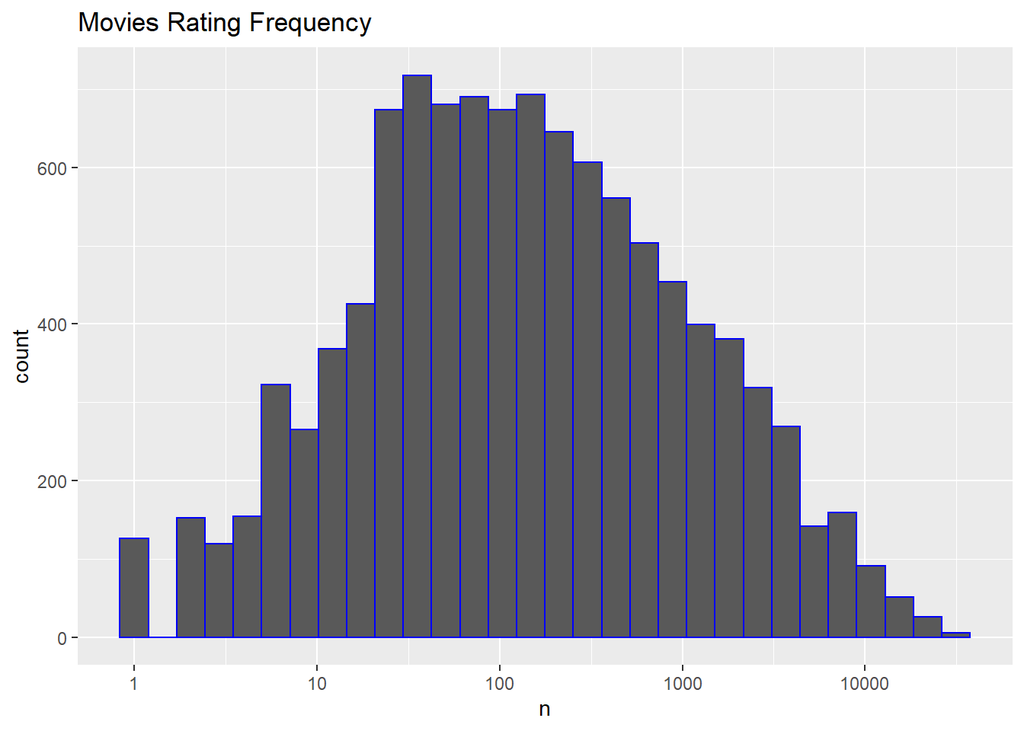